# Changes in trading account

## Portfolio

| symbol | close | closePerc | Total_Change_close | entry_price | position | position_size | entry_position | totalPerc | book_proceed | sector |
| --- | --- | --- | --- | --- | --- | --- | --- | --- | --- | --- |
| BRK.B | 212.5400 | 1.51 | 126.80 | 190.50387 | 40 | 8501.60 | 7620.1547 | 10.37 | 881.4453 | US Finance |
| EZA | 36.3250 | -0.26 | 19.00 | 38.54000 | -200 | -7265.00 | -7708.0000 | 6.10 | 443.0000 | Emerging markets |
| KWEB | 67.2600 | -0.99 | -67.00 | 70.04329 | 100 | 6726.00 | 7004.3290 | -4.14 | -278.3290 | Emerging markets |
| SEAS | 17.9000 | 5.85 | -371.25 | 17.96010 | -375 | -6712.50 | -6735.0375 | 0.34 | 22.5375 | US Retail |
| CAKE | 26.3300 | 1.94 | 75.00 | 23.14854 | 150 | 3949.50 | 3472.2814 | 12.08 | 477.2186 | US Retail |
| WPM | 52.7700 | -0.17 | -5.40 | 55.66323 | 60 | 3166.20 | 3339.7940 | -5.48 | -173.5940 | Metals |
| SLV | 27.0000 | 3.13 | 90.20 | 21.80151 | 110 | 2970.00 | 2398.1657 | 19.25 | 571.8343 | Metals |
| TSLA | 1419.0000 | -2.35 | -68.20 | 1425.00000 | 2 | 2838.00 | 2850.0000 | -0.42 | -12.0000 | US Tech |
| LMND | 67.3700 | 0.91 | 24.40 | 78.07124 | 40 | 2694.80 | 3122.8495 | -15.88 | -428.0495 | US Tech |
| JWN | 16.9000 | 5.49 | 132.00 | 14.09993 | 150 | 2535.00 | 2114.9900 | 16.57 | 420.0100 | US Retail |
| SQ | 139.2600 | -5.41 | -119.48 | 143.55799 | 15 | 2088.90 | 2153.3699 | -3.09 | -64.4699 | US Tech |
| V | 196.8900 | 0.25 | 5.00 | 194.66399 | 10 | 1968.90 | 1946.6399 | 1.13 | 22.2601 | US Finance |
| TPR | 15.4400 | 6.41 | 93.00 | 12.95000 | 100 | 1544.00 | 1295.0000 | 16.13 | 249.0000 | US Retail |
| GOOG | 1494.9500 | 0.07 | 0.99 | 1475.23040 | 1 | 1494.95 | 1475.2304 | 1.32 | 19.7196 | US Tech |
| GDX | 42.4100 | -0.86 | -12.95 | 43.89279 | 35 | 1484.35 | 1536.2475 | -3.50 | -51.8975 | Metals |
| SWKS | 143.5300 | -0.50 | -7.20 | 131.84990 | 10 | 1435.30 | 1318.4990 | 8.14 | 116.8010 | US Tech |
| RVLV | 19.0100 | 7.46 | 99.00 | 15.91993 | 75 | 1425.75 | 1193.9950 | 16.25 | 231.7550 | US Tech |
| PPLT | 93.0233 | 2.84 | 38.60 | 89.43657 | 15 | 1395.35 | 1341.5485 | 3.86 | 53.8010 | Metals |
| HD | 274.8800 | 1.17 | 15.95 | 266.53990 | 5 | 1374.40 | 1332.6995 | 3.03 | 41.7005 | US Retail |
| EPHE | 26.4700 | 1.38 | -18.00 | 25.66800 | -50 | -1323.50 | -1283.4000 | -3.03 | -40.1000 | Emerging markets |
| CRUS | 63.8400 | -1.21 | -15.60 | 71.60495 | 20 | 1276.80 | 1432.0990 | -12.16 | -155.2990 | US Tech |
| BBBY | 12.6700 | 4.62 | -56.00 | 11.01000 | -100 | -1267.00 | -1101.0000 | -13.10 | -166.0000 | US Retail |
| PALL | 208.5100 | 1.94 | 19.80 | 219.67990 | 5 | 1042.55 | 1098.3995 | -5.36 | -55.8495 | Metals |
| UPWK | 14.4800 | -2.56 | -26.98 | 14.48222 | 71 | 1028.08 | 1028.2379 | -0.02 | -0.1579 | US Tech |
| IAU | 19.3200 | -0.31 | -3.00 | 19.30000 | 50 | 966.00 | 965.0000 | 0.10 | 1.0000 | Metals |
| HLT | 86.1900 | 2.99 | -25.00 | 74.54000 | -10 | -861.90 | -745.4000 | -13.52 | -116.5000 | US Retail |
| GOLD | 28.7200 | -0.55 | -4.00 | 29.05000 | 25 | 718.00 | 726.2500 | -1.15 | -8.2500 | Metals |
| INDA | 33.0800 | 1.08 | 7.10 | 32.92990 | 20 | 661.60 | 658.5980 | 0.45 | 3.0020 | Emerging markets |
| FIZZ | 61.2100 | -3.23 | -20.40 | 68.19990 | 10 | 612.10 | 681.9990 | -11.42 | -69.8990 | US Retail |
| NFLX | 483.0000 | -2.42 | -11.98 | 486.00000 | 1 | 483.00 | 486.0000 | -0.62 | -3.0000 | US Tech |
| QQQ | 270.2800 | -0.45 | -1.22 | 258.75990 | 1 | 270.28 | 258.7599 | 4.26 | 11.5201 | US Tech |

| symbol | close | closePerc | Total_Change_close | entry_price | position | position_size | entry_position | totalPerc | book_proceed | sector |
| --- | --- | --- | --- | --- | --- | --- | --- | --- | --- | --- |
| Summary | NA | NA | -86.82 | NA | 1856 | 72081.31 | NA | 2.7 | 1943.21 | NA |

[interactive chart not shown]

The performance of my live stock portfolio/trading account vs. my paper trading account and the benchmark ‘SPY’, the US large cap stock market index ETF in percent since June 09 2020.

[interactive chart not shown]

This plot shows a summary of the trading activity on that day. Above 0 is a gain, below is a loss. TRUE indicated live trading account, FALSE is paper trading. A buy side trade is a closed short sale trade and sell side trade is a closed long trade.

[interactive chart not shown]

My current portfolio sorted by sectors. The plot reads clock-wise. Positions below 0 are short positions. Clicking a slice of the pie chart directs to marketwatch.com for further information.

[interactive chart not shown]

These two plots indicates the composition of my portfolio and the change of it over the past week.

[interactive chart not shown]

The inner circle is Monday, the outer circle is Friday.

[interactive chart not shown]

The colors in this plot indicate the daily percentage change of each stock in my portfolio.

[interactive chart not shown]

I classified the stocks in my portfolio by sector. The area represents the size of the position in the portfolio. Long postions

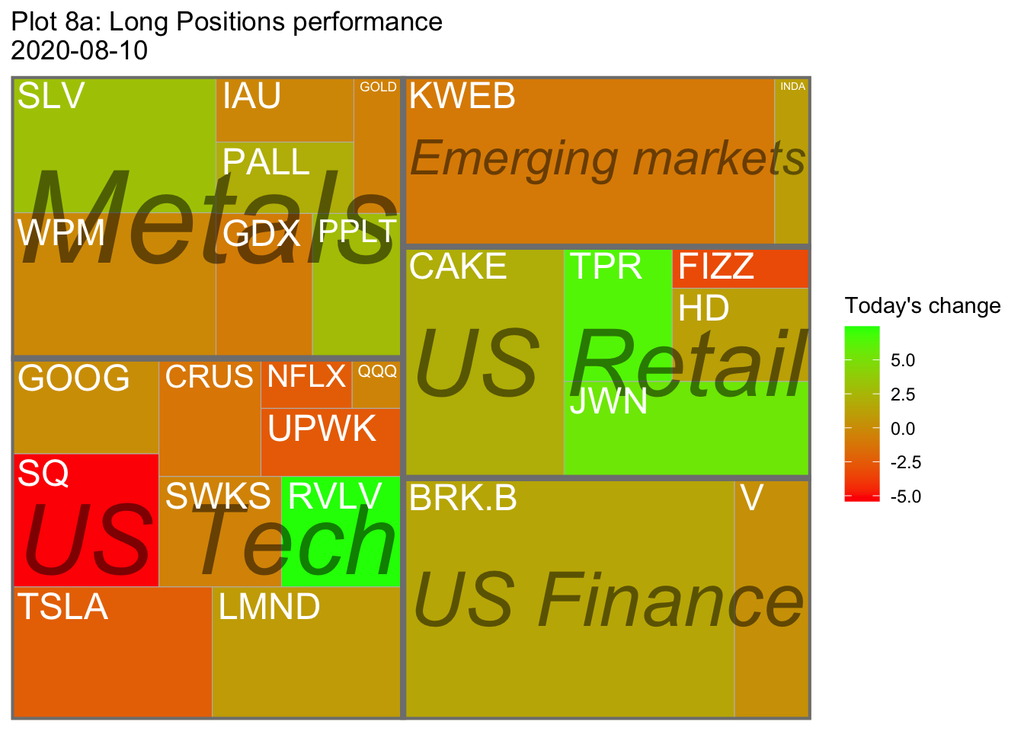

Short postions

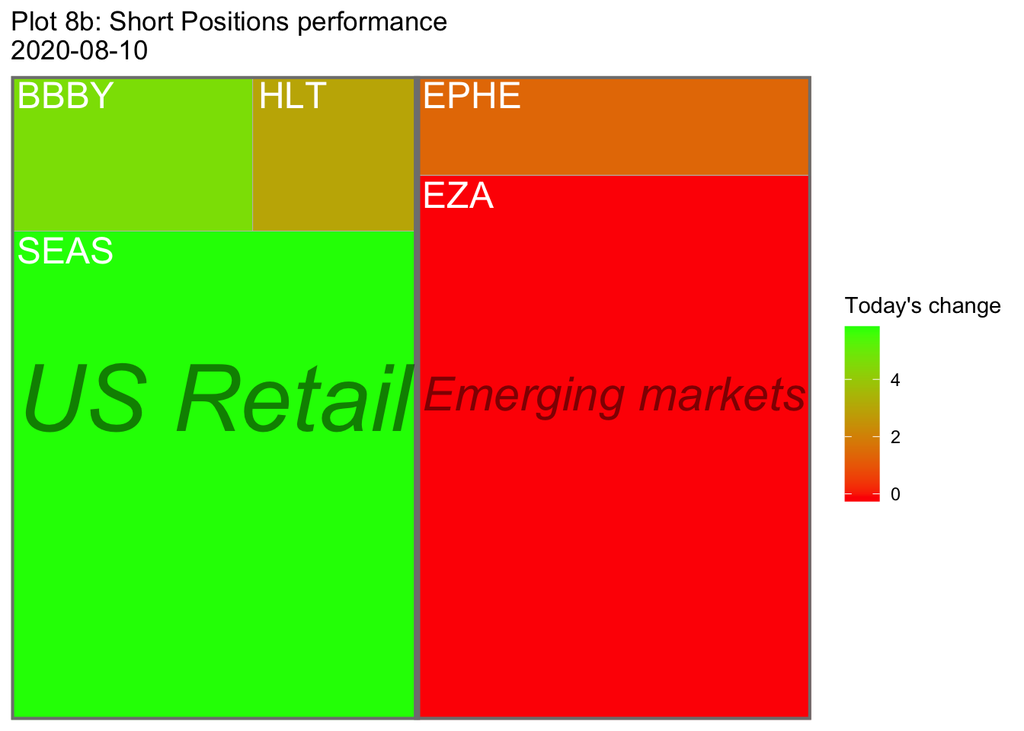

S&P 500 stocks colored by last day performance.

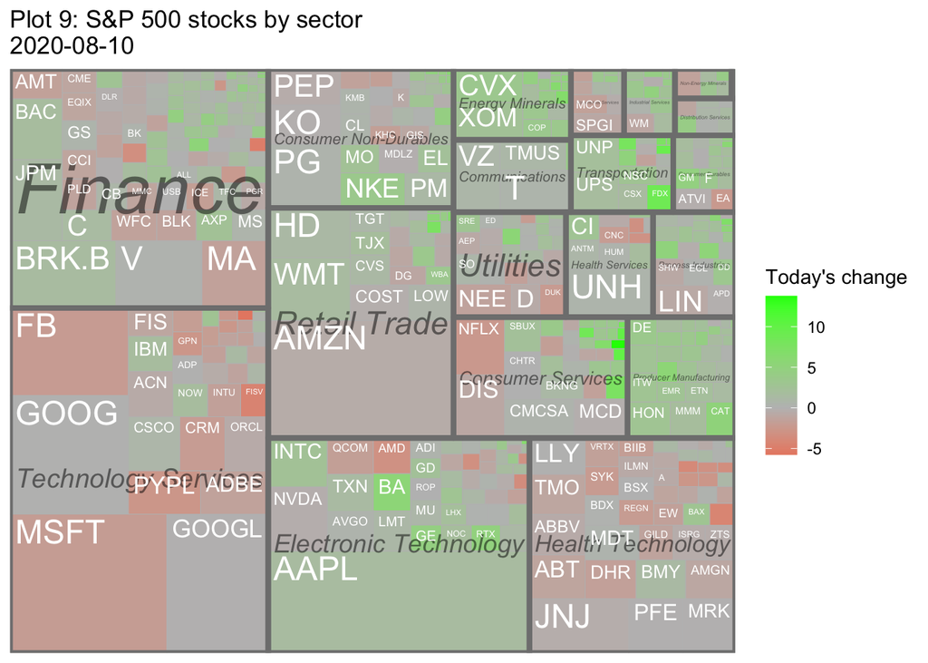

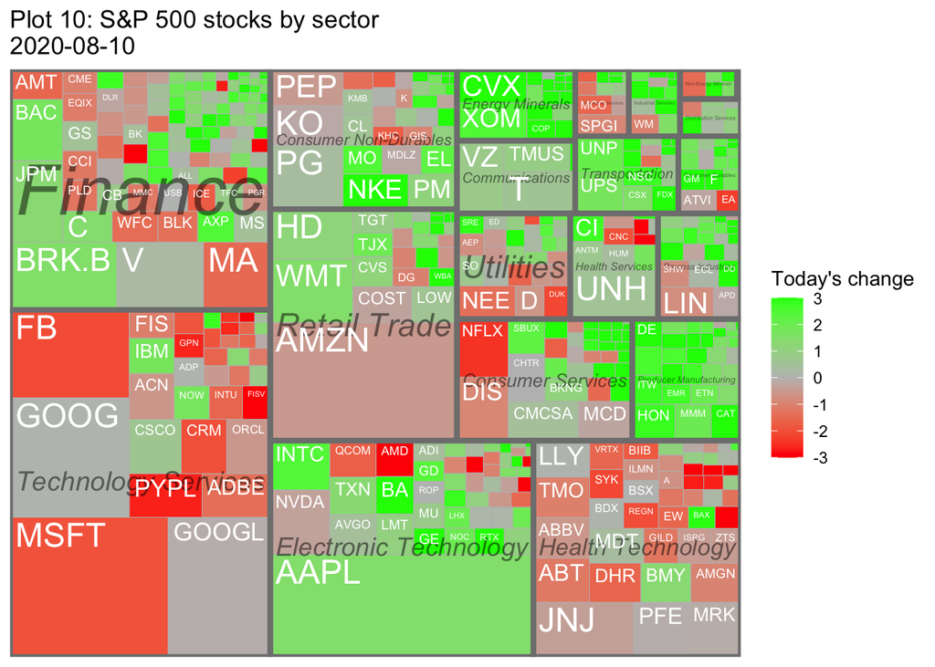

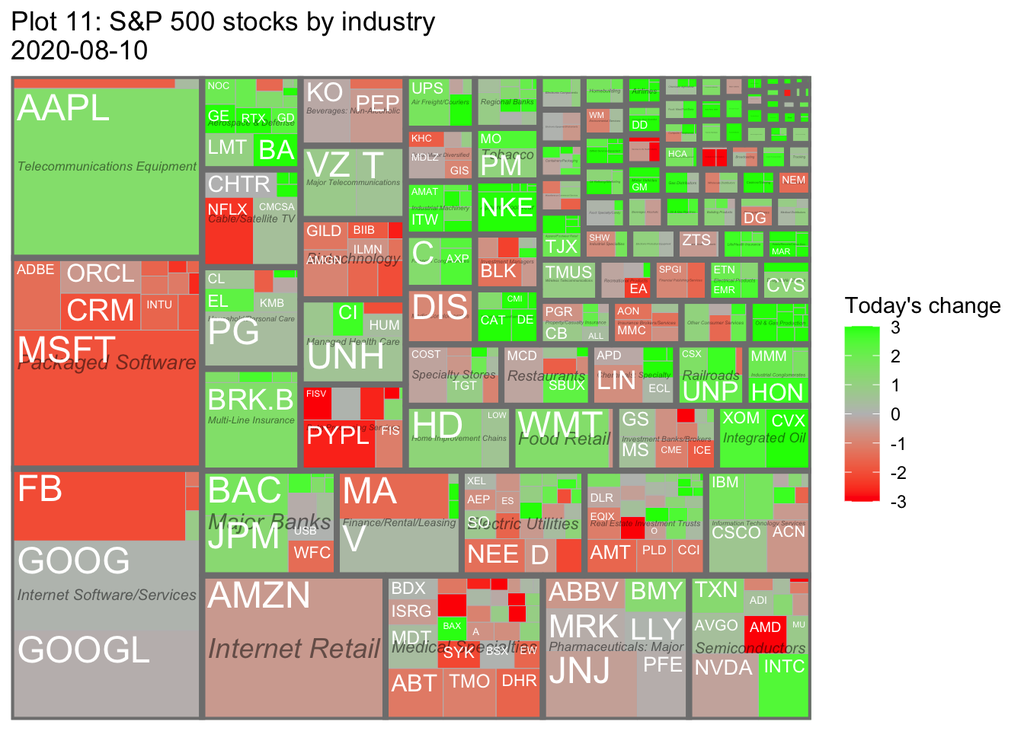